This assignment makes use of data from a personal activity monitoring device. This device collects data at 5 minute intervals throughout the day.

The data consists of two months of data from an anonymous individual collected during the months of October and November, 2012, including the number of steps taken in 5 minute intervals each day.

The first step of the analysis is to read the CSV file from the local working directory.

```r
setwd("~/Documents/Reproducible Research")
activity <- read.csv("activity.csv")
head(activity)
```

```
##   steps       date interval
## 1    NA 2012-10-01        0
## 2    NA 2012-10-01        5
## 3    NA 2012-10-01       10
## 4    NA 2012-10-01       15
## 5    NA 2012-10-01       20
## 6    NA 2012-10-01       25
```

```r
names(activity)
```

```
## [1] "steps"    "date"     "interval"
```

```r
str(activity)
```

```
## 'data.frame':    17568 obs. of  3 variables:
##  $ steps   : int  NA NA NA NA NA NA NA NA NA NA ...
##  $ date    : Factor w/ 61 levels "2012-10-01","2012-10-02",..: 1 1 1 1 1 1 1 1 1 1 ...
##  $ interval: int  0 5 10 15 20 25 30 35 40 45 ...
```

The variables included in this dataset are:

- steps: Number of steps taking in a 5-minute interval (missing values are coded as NA)
- date: The date on which the measurement was taken in YYYY-MM-DD format
- interval: Identifier for the 5-minute interval in which measurement was taken

Next, with the R script below, create a histogram of the total steps taken each day of the study period and calculate the mean and median of the total number of steps taken per day.

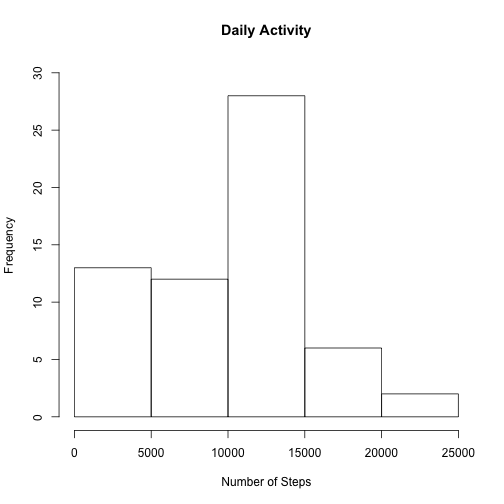

```r
daily_activity <- aggregate(activity$steps,by = list(activity$date), sum, na.rm = TRUE)
hist(daily_activity$x, xlab = "Number of Steps", main = "Daily Activity", ylim = c(0,30))
```

```r
mean_daily <- mean(daily_activity$x)
median_daily <- median(daily_activity$x)

mean_daily
```

```
## [1] 9354.23
```

```r
median_daily
```

```
## [1] 10395
```

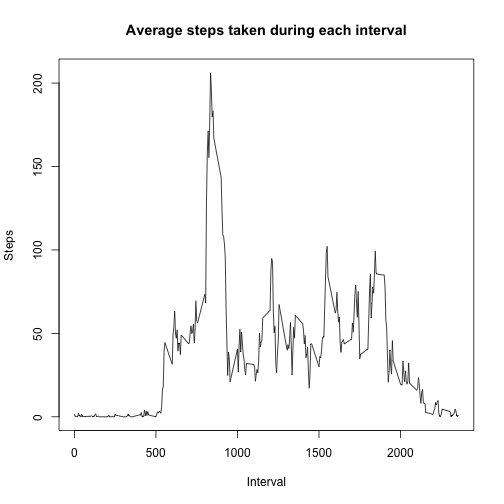

```r
interval_activity <- aggregate(activity$steps, by = list(activity$interval), mean, na.rm = TRUE)
plot(interval_activity$Group.1,interval_activity$x, type = "l", main = "Average steps taken during each interval", xlab = "Interval", ylab = "Steps")
```

```r
max_interval <- max(interval_activity$x)
max_interval
```

```
## [1] 206.1698
```

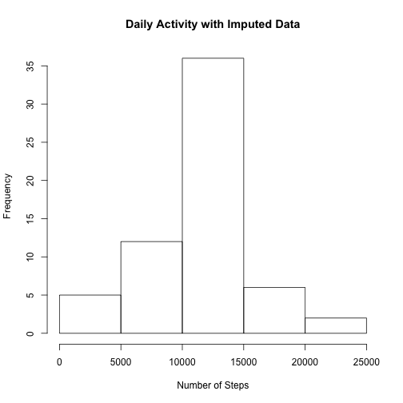

```r
na_count <- sum(is.na(activity$steps))

colnames(interval_activity) <- c("interval", "Average_Interval_Steps")
activity_imputed <- merge(activity,interval_activity,by="interval")
activity_imputed[is.na(activity_imputed$steps),]$steps <- activity_imputed[is.na(activity_imputed$steps),]$Average_Interval_Steps

daily_activity_imputed <- aggregate(activity_imputed$steps, by = list(activity_imputed$date), sum)

hist(daily_activity_imputed$x, xlab = "Number of Steps", main = "Daily Activity with Imputed Data")
```

```r
mean_daily_imputed <- mean(daily_activity_imputed$x)
median_daily_imputed <- median(daily_activity_imputed$x)

mean_daily_imputed
```

```
## [1] 10766.19
```

```r
median_daily_imputed
```

```
## [1] 10766.19
```

Finally, make a panel plot containing a time series plot of the 5-minute interval and the average number of steps taken, averaged across all weekday days or weekend days.

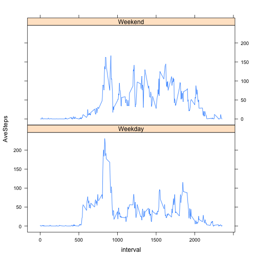

```r
activity_imputed$weekdayInd<-with(activity_imputed, !(weekdays(as.Date(activity_imputed$date))=="Saturday" | weekdays(as.Date(activity_imputed$date))=="Sunday"))

activity_imputed$TimePeriod[activity_imputed$weekdayInd==0]<-"Weekend"
activity_imputed$TimePeriod[activity_imputed$weekdayInd==1]<-"Weekday"
library(dplyr)
activity_imputed.SMRY <- group_by(activity_imputed, TimePeriod,interval)
activity_imputed.SMRY<-summarize(activity_imputed.SMRY, AveSteps = mean(steps, na.rm = TRUE))
library(lattice)
xyplot(AveSteps ~ interval | TimePeriod, data = activity_imputed.SMRY, layout = c(1, 2),type = "l")
```